# IGT - Data Cleaning, Summary, and Visualizations

Charlie Whittaker

2/20/2026

```r
library(openxlsx)
library(tidyverse)
library(ggrepel)
library(ggpubr)
library(purrr)
library(knitr)
library(lubridate)
library(patchwork)
```

# Data Import

## Read in ilabs stock data and select Biopolymers rows

Select both cores with MIT BioMicro Center in name and filter out HTS charges

```r
ilabs <- read.xlsx("../data/stock_ilabs.xlsx")
ilabs.igt <- ilabs %>% dplyr::filter(Core.Name %in% c("KI Genomics Core / MIT BioMicro Center","KI Genomics Core / MIT BioMicro Center and KI High Throughput Sciences Core"))
cat("Dimensions of ilabs.igt:", dim(ilabs.igt), "\n")
```

```
## Dimensions of ilabs.igt: 26881 19
```

```r
ilabs.igt <- ilabs.igt %>% dplyr::filter(!(Category == "Technical Assistance" & stringr::str_starts(Charge.Name, "HTS")))
cat("Dimensions of ilabs.igt:", dim(ilabs.igt), "\n")
```

```
## Dimensions of ilabs.igt: 26820 19
```

```r
rm(ilabs)
```

### Repair ilabs date

```r
ilabs.igt$Purchase.Date <- as.Date(ilabs.igt$Purchase.Date, origin = "1899-12-30")
```

### Check year table to make sure the 2 cores are just a rename - they are, rename started in 2024

```r
ilabs.igt %>%
  dplyr::mutate(Year = lubridate::year(Purchase.Date)) %>%
  dplyr::count(Year, Core.Name) %>%
  tidyr::pivot_wider(names_from = Year, values_from = n, values_fill = 0)
```

```
## # A tibble: 2 × 7
##   Core.Name                            `2020` `2021` `2022` `2023` `2024` `2025`
##   <chr>                                 <int>  <int>  <int>  <int>  <int>  <int>
## 1 KI Genomics Core / MIT BioMicro Cen…   4690   5895   4960   4249   2993      0
## 2 KI Genomics Core / MIT BioMicro Cen…      0      0      0      0    545   3488
```

## Read in bmc-external and repair problems

Some code has been added here to fix a unprintable character problem

```r
bmc.ext <- read.xlsx("../data/ExtUsage2025_2510.xlsx") %>%
  mutate(LAB = stringr::str_replace_all(LAB, "_x000B_", ""))
```

Some LAB values are empty, replace them with external

```r
bmc.ext <- bmc.ext %>% dplyr::mutate(LAB = if_else(is.na(LAB), "external", LAB))
```

Some NUM values are NA, replace them with 1

```r
bmc.ext <- bmc.ext %>% mutate(NUM = replace_na(NUM, 1))
```

Some COST values are NA

```r
bmc.ext <- bmc.ext %>% mutate(COST = replace_na(COST, 1))
```

### Data Repair - bmc external

#### simplify the imported dataframe

This first step identifies empty or near-empty columns and summarizes the results. The bmc.ext data as none of these low complexity columns.

```r
# simple.cols <- map_df(names(bmc.ext), ~{
#   col <- bmc.ext[[.]]
#   n_unique <- n_distinct(col[!is.na(col)])
#
#   tibble(
#     column = .,
#     value = if_else(all(is.na(col)),
#                     "empty",
#                     if_else(n_unique == 1,
#                            as.character(unique(col[!is.na(col)])[1]),
#                            NA_character_))
#   )
# }) %>%
#   filter(!is.na(value))
#
# kable(simple.cols, format = "simple")
```

If the data frame had these columns, they could be excluded with this code.

```r
# cat("Dimensions before simple column exclusion:", dim(bmc.ext), "\n")
# bmc.ext <- bmc.ext %>% dplyr::select(-all_of(simple.cols$column))
# cat("Dimensions after simple column exclusion:", dim(bmc.ext), "\n")
```

#### Repair date

```r
bmc.ext$Purchase.Date <- as.Date(bmc.ext$DATE, origin = "1899-12-30")
```

#### Exclude DSMI-related charges from bmc.ext

```r
bmc.ext.igt <- bmc.ext %>% dplyr::filter(!TYPE %in% c("Bioinformatics", "Computing"))
```

#### Compare column names in ilabs.dsmi and bmc.ext

```r
colnames(ilabs.igt)
```

```
##  [1] "Service.ID"          "Service.Type"        "Customer.Name"
##  [4] "Customer.Lab"        "Customer.Department" "Customer.Institute"
##  [7] "Charge.Name"         "Notes"               "Unit.of.Measure"
## [10] "Quantity"            "Price"               "Total.Price"
## [13] "Price.Type"          "Purchase.Date"       "Core.Name"
## [16] "Charge.ID"           "Center"              "Category"
## [19] "Usage.Type"
```

```r
colnames(bmc.ext.igt)
```

```
##  [1] "_ID"           "PROJID"        "LAB"           "USER"
##  [5] "DATE"          "DETAIL"        "NUM"           "COST"
##  [9] "CostObj"       "TargetObject"  "TYPE"          "Purchase.Date"
```

#### Rename columns to match ilabs

```r
bmc.ext.igt <- bmc.ext.igt %>% dplyr::rename(Customer.Name = USER)
bmc.ext.igt <- bmc.ext.igt %>% dplyr::mutate(Service.ID = `_ID`)
bmc.ext.igt <- bmc.ext.igt %>% dplyr::rename(Customer.Lab = LAB)
bmc.ext.igt <- bmc.ext.igt %>% dplyr::rename(Charge.Name = DETAIL)
bmc.ext.igt <- bmc.ext.igt %>% dplyr::rename(Quantity = NUM)
bmc.ext.igt <- bmc.ext.igt %>% dplyr::rename(Total.Price = COST)
bmc.ext.igt <- bmc.ext.igt %>% dplyr::rename(Category = TYPE)
```

#### Add missing columns needed to match ilabs data

```r
bmc.ext.igt <- bmc.ext.igt %>% dplyr::mutate(Price = round(Total.Price/Quantity,2))
bmc.ext.igt <- bmc.ext.igt %>% dplyr::mutate(Service.Type = "ToUpdate")
bmc.ext.igt <- bmc.ext.igt %>% dplyr::mutate(Customer.Department = "")
bmc.ext.igt <- bmc.ext.igt %>% dplyr::mutate(Customer.Institute = "")
bmc.ext.igt <- bmc.ext.igt %>% dplyr::mutate(Unit.of.Measure = "ToUpdate")
bmc.ext.igt <- bmc.ext.igt %>% dplyr::mutate(Price.Type = "")
bmc.ext.igt <- bmc.ext.igt %>% dplyr::mutate(Core.Name = "bmc.ext")
bmc.ext.igt <- bmc.ext.igt %>% dplyr::mutate(Center = "")
bmc.ext.igt <- bmc.ext.igt %>% dplyr::mutate(Usage.Type = "")
bmc.ext.igt <- bmc.ext.igt %>% dplyr::mutate(Notes = "")
bmc.ext.igt <- bmc.ext.igt %>% dplyr::mutate(Charge.ID = "")
```

#### Select ilabs columns from bmc.ext.igt

```r
bmc.ext.igt.to_rbind <- bmc.ext.igt %>%
  dplyr::select(Service.ID, Service.Type, Customer.Name, Customer.Lab, Customer.Department,
                Customer.Institute, Charge.Name, Notes, Unit.of.Measure, Quantity, Price,
                Total.Price, Price.Type, Purchase.Date, Core.Name, Charge.ID, Center, Category,
                Usage.Type)
```

#### Check the column names

```r
colnames(ilabs.igt)
```

```
##  [1] "Service.ID"          "Service.Type"        "Customer.Name"
##  [4] "Customer.Lab"        "Customer.Department" "Customer.Institute"
##  [7] "Charge.Name"         "Notes"               "Unit.of.Measure"
## [10] "Quantity"            "Price"               "Total.Price"
## [13] "Price.Type"          "Purchase.Date"       "Core.Name"
## [16] "Charge.ID"           "Center"              "Category"
## [19] "Usage.Type"
```

```r
colnames(bmc.ext.igt.to_rbind)
```

```
##  [1] "Service.ID"          "Service.Type"        "Customer.Name"
##  [4] "Customer.Lab"        "Customer.Department" "Customer.Institute"
##  [7] "Charge.Name"         "Notes"               "Unit.of.Measure"
## [10] "Quantity"            "Price"               "Total.Price"
## [13] "Price.Type"          "Purchase.Date"       "Core.Name"
## [16] "Charge.ID"           "Center"              "Category"
## [19] "Usage.Type"
```

### Join ilabs and bmc.ext.igt

```r
igt.final <- rbind(ilabs.igt,bmc.ext.igt.to_rbind)
```

### Exclude HTS rows using Category information

```r
igt.final <- igt.final %>% dplyr::filter(!stringr::str_starts(Category, "HTS"))
```

### Check dates before reporting range selection

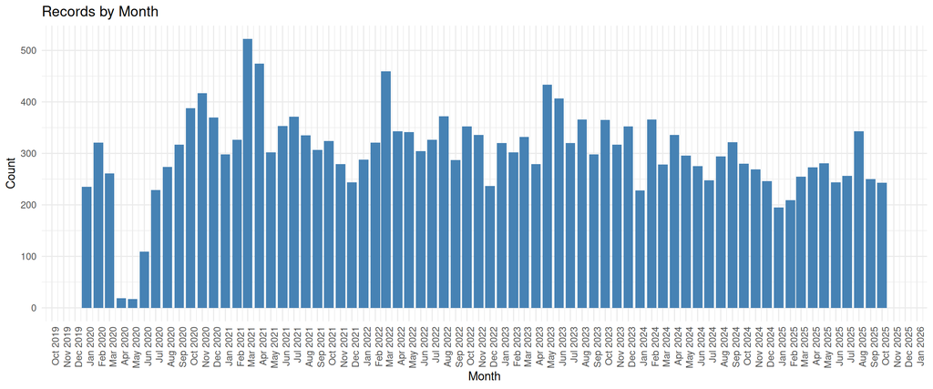

```r
igt.final %>%
  mutate(Year_Month = floor_date(Purchase.Date, "month")) %>%
  count(Year_Month) %>%
  arrange(Year_Month) %>%
  ggplot(aes(x = Year_Month, y = n)) +
  geom_col(fill = "steelblue") +
  scale_x_date(date_labels = "%b %Y", date_breaks = "1 month") +
  labs(title = "Records by Month",
       x = "Month",
       y = "Count") +
  theme_minimal() +
  theme(axis.text.x = element_text(angle = 90, hjust = 1))
```

### Select reporting date range

```r
cat("Dimensions of igt.final before reporting range selection:", dim(igt.final), "\n")
```

```
## Dimensions of igt.final before reporting range selection: 21136 19
```

```r
igt.final <- igt.final %>% dplyr::filter(between(Purchase.Date, as.Date("2020-05-01"), as.Date("2025-10-31")))
cat("Dimensions of igt.final after reporting range selection:", dim(igt.final), "\n")
```

```
## Dimensions of igt.final after reporting range selection: 20291 19
```

### Check dates after reporting range selection

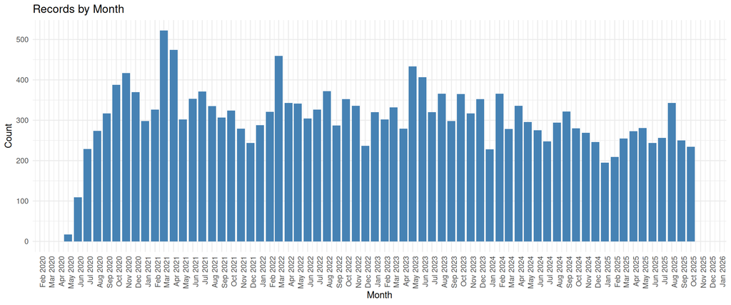

```r
igt.final %>%
  mutate(Year_Month = floor_date(Purchase.Date, "month")) %>%
  count(Year_Month) %>%
  arrange(Year_Month) %>%
  ggplot(aes(x = Year_Month, y = n)) +
  geom_col(fill = "steelblue") +
  scale_x_date(date_labels = "%b %Y", date_breaks = "1 month") +
  labs(title = "Records by Month",
       x = "Month",
       y = "Count") +
  theme_minimal() +
  theme(axis.text.x = element_text(angle = 90, hjust = 1))
```

# Faculty Annotation Work

### Import faculty key data

```r
fac.key <- read.xlsx("../data/FacultyKeys.xlsx")
```

### Associate Faculty.Key with igt.final

```r
igt.final <- igt.final %>%
  left_join(fac.key %>%
              select(ValueInData, Faculty.Key) %>%
              distinct(),
            by = c("Customer.Lab" = "ValueInData"))
```

### Import sponsor annotation data

```r
fac.annot <- read.xlsx("../data/annotated.Faculty.Keys.xlsx")
```

### Join to igt.final using Faculty.Key

```r
igt.final <- igt.final %>%
  dplyr::left_join(
    fac.annot %>% dplyr::select(Faculty.Key, IGT_DSMI_Sponsor),
    by = "Faculty.Key"
  )
```

#### Check for missing Faculty.Key or IGT_DSMI_Sponsor values

```r
igt.final %>% dplyr::filter(is.na(Faculty.Key))
```

```
##  [1] Service.ID          Service.Type        Customer.Name
##  [4] Customer.Lab        Customer.Department Customer.Institute
##  [7] Charge.Name         Notes               Unit.of.Measure
## [10] Quantity            Price               Total.Price
## [13] Price.Type          Purchase.Date       Core.Name
## [16] Charge.ID           Center              Category
## [19] Usage.Type          Faculty.Key         IGT_DSMI_Sponsor
## <0 rows> (or 0-length row.names)
```

```r
igt.final %>% dplyr::filter(is.na(IGT_DSMI_Sponsor))
```

```
##  [1] Service.ID          Service.Type        Customer.Name
##  [4] Customer.Lab        Customer.Department Customer.Institute
##  [7] Charge.Name         Notes               Unit.of.Measure
## [10] Quantity            Price               Total.Price
## [13] Price.Type          Purchase.Date       Core.Name
## [16] Charge.ID           Center              Category
## [19] Usage.Type          Faculty.Key         IGT_DSMI_Sponsor
## <0 rows> (or 0-length row.names)
```

### Simplify sponsor associations for plotting

#### Import simplified categories

```r
sponsor.toPlot <- read.xlsx("../data/sponsor.Keys.ForPlotting.xlsx")
sponsor.toPlot
```

```
##           Sponsor Sponsor_ForPlot
## 1       KI_member   Center_Member
## 2    KI_affiliate   Center_Member
## 3     MIT_sponsor     MIT_Sponsor
## 4 MIT_non_sponsor     Non_Sponsor
## 5        external     Non_Sponsor
## 6        industry     Non_Sponsor
```

#### Join simplified sponsor data to igt.final

```r
igt.final <- igt.final %>%
  dplyr::left_join(sponsor.toPlot, by = c("IGT_DSMI_Sponsor" = "Sponsor"))
```

#### Check for missing Sponsor_ForPlot values

```r
igt.final %>% dplyr::filter(is.na(Sponsor_ForPlot))
```

```
##  [1] Service.ID          Service.Type        Customer.Name
##  [4] Customer.Lab        Customer.Department Customer.Institute
##  [7] Charge.Name         Notes               Unit.of.Measure
## [10] Quantity            Price               Total.Price
## [13] Price.Type          Purchase.Date       Core.Name
## [16] Charge.ID           Center              Category
## [19] Usage.Type          Faculty.Key         IGT_DSMI_Sponsor
## [22] Sponsor_ForPlot
## <0 rows> (or 0-length row.names)
```

# Service Annotation

## Parse Charge.Name

```r
igt.final <- igt.final %>% dplyr::mutate(Charge.Name.Short = stringr::str_trim(stringr::str_extract(Charge.Name, "^[^|]*")))
```

### Check for empty or NA rows, if 0 is reported, there are none

```r
sum(is.na(igt.final$Charge.Name.Short)) + sum(igt.final$Charge.Name.Short == "", na.rm = TRUE)
```

```
## [1] 0
```

## Prepare and export different usage sets

```r
Charge.Name.Short.table <- as.data.frame(table(igt.final$Charge.Name.Short))
Charge.Name.Short.table <- dplyr::rename(Charge.Name.Short.table,Charge.Name.Short = Var1,RowCount = Freq)
write.xlsx(Charge.Name.Short.table,file="ChargeNameShortTable.xlsx")
```

### Import manually annotated Charge.Name.Short file

```r
Charge.Name.Short.table.annot <- read.xlsx("ChargeNameShortTable_annotated.xlsx")
```

### Join Charge.Name.Short annotations to igt.final

Make a copy of igt.final so it is easier to restart

```r
igt.final.annot <- igt.final
```

Complete the join

```r
cat("Dimensions of igt.final.annot before joining annotations:", dim(igt.final.annot), "\n")
```

```
## Dimensions of igt.final.annot before joining annotations: 20291 23
```

```r
igt.final.annot <- igt.final.annot %>%
  dplyr::left_join(Charge.Name.Short.table.annot, by = c("Charge.Name.Short" = "Charge.Name.Short"))
cat("Dimensions of igt.final.annot after joining annotations:", dim(igt.final.annot), "\n")
```

```
## Dimensions of igt.final.annot after joining annotations: 20291 27
```

#### Check for missing group annotations

```r
igt.final.annot %>% dplyr::filter(is.na(group))
```

```
##  [1] Service.ID              Service.Type            Customer.Name
##  [4] Customer.Lab            Customer.Department     Customer.Institute
##  [7] Charge.Name             Notes                   Unit.of.Measure
## [10] Quantity                Price                   Total.Price
## [13] Price.Type              Purchase.Date           Core.Name
## [16] Charge.ID               Center                  Category
## [19] Usage.Type              Faculty.Key             IGT_DSMI_Sponsor
## [22] Sponsor_ForPlot         Charge.Name.Short       RowCount
## [25] group                   Unit.of.Measure.ForNorm normalization
## <0 rows> (or 0-length row.names)
```

#### Exclude Training rows in Usage.Type.ToExclude

Sample isolation, purification, and initial processing hour relative.spent Training Library Preparation, Automation, and Quality Control hour relative.spent [TRAINING SESSION] OR [ASSISTED USE]

March 9, 2026 - after discussion SF decided to include the following lines in the pie chart so excludes commented out

```r
# cat("Dimensions of igt.final.annot before excluding:", dim(igt.final.annot), "\n")
# igt.final.annot <- igt.final.annot %>%
#   dplyr::filter(!(group == "Sample isolation, purification, and initial processing" & Usage.Type == "Training"))
# cat("Dimensions of igt.final.annot after excluding:", dim(igt.final.annot), "\n")
# igt.final.annot <- igt.final.annot %>%
#   dplyr::filter(!(group == "Library Preparation, Automation, and Quality Control" & Usage.Type %in% c("[TRAINING SESSION]","[ASSISTED USE]")))
# cat("Dimensions of igt.final.annot after 2nd exclude:", dim(igt.final.annot), "\n")
```

#### Incorporate Stuart’s manual annotations

Split igt.final.annot into 2 groups, one without meaningful group annotation, one with

```r
rows.NoGroup <- igt.final.annot %>% dplyr::filter(group == "assistance")
rows.WithGroup <- igt.final.annot %>% dplyr::filter(group != "assistance")
```

Add a temporary key to transfer data

```r
rows.NoGroup <- rows.NoGroup %>% mutate(TmpTransferKey = paste0(Service.ID,Charge.Name.Short,Quantity))
```

Column Checks - this reports the number of unique values in the columns

```r
rows.NoGroup %>% summarize(across(everything(), n_distinct)) %>% as.data.frame() %>% t()
```

```
##                         [,1]
## Service.ID                98
## Service.Type              11
## Customer.Name             56
## Customer.Lab              40
## Customer.Department        1
## Customer.Institute         3
## Charge.Name                3
## Notes                     53
## Unit.of.Measure            2
## Quantity                  67
## Price                     12
## Total.Price               74
## Price.Type                 4
## Purchase.Date             85
## Core.Name                  3
## Charge.ID                 59
## Center                     3
## Category                   5
## Usage.Type                 2
## Faculty.Key               34
## IGT_DSMI_Sponsor           6
## Sponsor_ForPlot            3
## Charge.Name.Short          2
## RowCount                   2
## group                      1
## Unit.of.Measure.ForNorm    1
## normalization              1
## TmpTransferKey           105
```

#### Import Stuart’s annotations

```r
sl.annot <- read.xlsx("igt.assistance.need allocation_SLcwFix.xlsx")
```

Add a temporary key to transfer data

```r
sl.annot <- sl.annot %>% mutate(TmpTransferKey = paste0(Service.ID,Charge.Name.Short,Quantity))
```

Extract the tmp key and stuart’s annotations

```r
sl.annot <- sl.annot %>% dplyr::select(TmpTransferKey, group)
sl.annot <- sl.annot %>% rename(sl.group = group)
```

Check the number of matches between sl annotations and noGroup file:

```r
matches <- intersect(rows.NoGroup$TmpTransferKey, sl.annot$TmpTransferKey)
cat("Matching TmpTransferKeys:", length(matches), "\n")
```

```
## Matching TmpTransferKeys: 105
```

Join sl.group to rows.NoGroup

```r
rows.NoGroup <- rows.NoGroup %>%
  left_join(sl.annot %>% select(TmpTransferKey, sl.group),
            by = "TmpTransferKey")
```

Move new sl.group values to group and get rid of extra columns

```r
rows.NoGroup <- rows.NoGroup %>%
  mutate(group = sl.group) %>%
  select(-TmpTransferKey, -sl.group)
```

Re-assemble igt.final.annot

```r
igt.final.annot <- rbind(rows.WithGroup,rows.NoGroup)
```

### Add rate modifiers and adjusted Total.price

Create rate modifier dataframe

```r
rate_modifiers <- tibble(
  IGT_DSMI_Sponsor = c("KI_member", "KI_affiliate", "MIT_sponsor", "MIT_non_sponsor", "external", "industry"),
  RateModifier = c(1, 1, 1, 1.1, 1.25, 1.4)
)
```

Join to igt.final.annot

```r
igt.final.annot <- igt.final.annot %>%
  left_join(rate_modifiers,
            by = "IGT_DSMI_Sponsor")
```

Check the join

```r
table(igt.final.annot$IGT_DSMI_Sponsor,igt.final.annot$RateModifier)
```

```
##
##                      1  1.1 1.25  1.4
##   external           0    0  360    0
##   industry           0    0    0  329
##   KI_affiliate    1292    0    0    0
##   KI_member       8039    0    0    0
##   MIT_non_sponsor    0 3345    0    0
##   MIT_sponsor     6926    0    0    0
```

Calculate adjusted price column for pie charts

```r
igt.final.annot <- igt.final.annot %>% mutate(Adjusted.Total.Price = Total.Price / RateModifier)
```

# Data Visualizations

## Define Color Palette

```r
# Define colors for each Sponsor (adjust these hex codes as needed)
# Original palette
# sponsor_colors <- c(
#   "Center_Member" = "steelblue2",
#   "MIT_Sponsor" = "orange",
#   "Non_Sponsor" = "#C16644"
# )

# Colorblind safe 3
sponsor_colors <- c(
  "Center_Member" = "#56B4E9",
  "MIT_Sponsor" = "#E69F00",
  "Non_Sponsor" = "#009E73"
)

# Define order of sponsors for stacking (top to bottom)
sponsor_order <- c("Center_Member", "MIT_Sponsor", "Non_Sponsor")
```

## Sample isolation, purification, and initial processing

```r
samp <- igt.final.annot %>% dplyr::filter(group == "Sample isolation, purification, and initial processing")
cat("Rows in sample:", dim(samp)[1], "\n")
```

```
## Rows in sample: 1116
```

```r
table(samp$Charge.Name.Short,samp$Unit.of.Measure)
```

```
##
##                                                                         each
##   Chemagic360                                                              0
##   Chemagic360 - DNA                                                       10
##   Chemagic360 - RNA                                                       40
##   Cleanup Charge - preclean samples before Illumina library preparation  281
##   Covaris E220 usage                                                       0
##   Covaris E220 Usage                                                       0
##   Covaris Sonicator                                                        0
##   Custom: Amplification & Cleanup of samples                               0
##   HTL - Cleanup                                                            0
##   HTL - Setup                                                              0
##   NamoCell Single Cell Sorter                                              0
##   RNA isolation - FFPE  Scroll                                             7
##   Sample quantification for high throughput library preparation          119
##   Setup Charge - Normalization and arraying for HTL preps (48 samples)   269
##
##                                                                         hour
##   Chemagic360                                                             44
##   Chemagic360 - DNA                                                        0
##   Chemagic360 - RNA                                                        0
##   Cleanup Charge - preclean samples before Illumina library preparation    0
##   Covaris E220 usage                                                       0
##   Covaris E220 Usage                                                       0
##   Covaris Sonicator                                                      246
##   Custom: Amplification & Cleanup of samples                               0
##   HTL - Cleanup                                                            0
##   HTL - Setup                                                              0
##   NamoCell Single Cell Sorter                                             27
##   RNA isolation - FFPE  Scroll                                             0
##   Sample quantification for high throughput library preparation            0
##   Setup Charge - Normalization and arraying for HTL preps (48 samples)     0
##
##                                                                         ToUpdate
##   Chemagic360                                                                  0
##   Chemagic360 - DNA                                                            0
##   Chemagic360 - RNA                                                            0
##   Cleanup Charge - preclean samples before Illumina library preparation        0
##   Covaris E220 usage                                                           1
##   Covaris E220 Usage                                                           1
##   Covaris Sonicator                                                            0
##   Custom: Amplification & Cleanup of samples                                   1
##   HTL - Cleanup                                                               30
##   HTL - Setup                                                                 40
##   NamoCell Single Cell Sorter                                                  0
##   RNA isolation - FFPE  Scroll                                                 0
##   Sample quantification for high throughput library preparation                0
##   Setup Charge - Normalization and arraying for HTL preps (48 samples)         0
```

### Prepare Sample isolation, purification, and initial processing pie chart

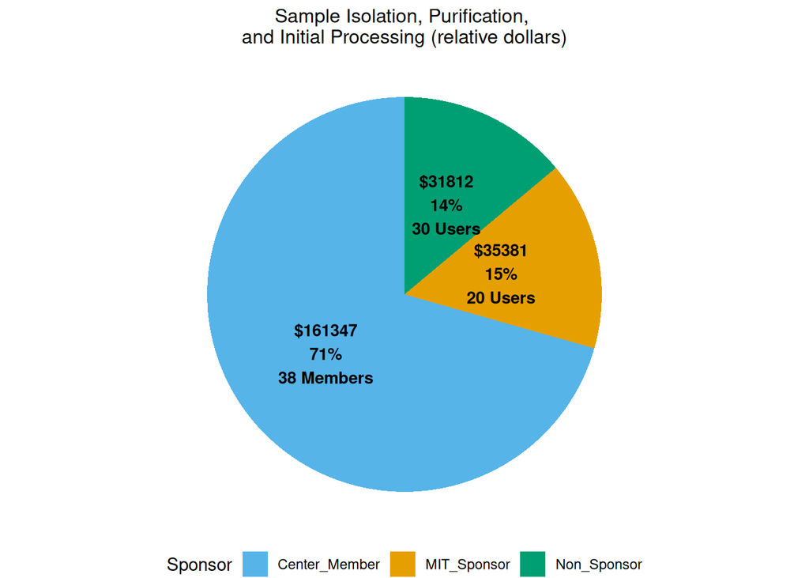

```r
samp.pie <- samp %>%
  mutate(Sponsor_ForPlot = factor(Sponsor_ForPlot, levels = sponsor_order)) %>%
  group_by(Sponsor_ForPlot) %>%
  summarise(Quantity = sum(round(Adjusted.Total.Price,0)),
            Num_Labs = if_else(first(Sponsor_ForPlot) == "Center_Member",
                               n_distinct(Faculty.Key[IGT_DSMI_Sponsor == "KI_member"]),
                               n_distinct(Faculty.Key)),
            .groups = "drop") %>%
  mutate(Percent = round((Quantity / sum(Quantity)) * 100, 0),
         Lab_Label = if_else(Sponsor_ForPlot == "Center_Member",
                             paste0(Num_Labs, " Members"),
                             paste0(Num_Labs, " Users")),
         Label = paste0("$",Quantity, "\n", Percent, "%\n", Lab_Label)) %>%
  ggplot(aes(x = "", y = Quantity, fill = Sponsor_ForPlot)) +
  geom_col() +
  geom_text(aes(label = Label),
            position = position_stack(vjust = 0.5),
            size = 3.6,
            fontface = "bold",
            color = "black") +
  coord_polar("y", start = 0) +
  scale_fill_manual(values = sponsor_colors) +
  labs(title = "Sample Isolation, Purification, \nand Initial Processing (relative dollars)",
       fill = "Sponsor") +
  theme_void() +
  theme(legend.position = "bottom",
        plot.title = element_text(size = 12,
                                  face = "plain",
                                  hjust = 0.5))
samp.pie
```

## Library preparation, automation, and quality control

```r
lib <- igt.final.annot %>% dplyr::filter(group == "Library Preparation, Automation, and Quality Control")
cat("Rows lib:", dim(lib)[1], "\n")
```

```
## Rows lib: 13493
```

```r
table(lib$Charge.Name.Short,lib$Unit.of.Measure)
```

```
##
##                                                                   each hour
##   16S ribosome (v4) (add'l 48 samples)                              22    0
##   16S ribosome (v4) (per 44 samples + 4 controls)                   37    0
##   40 DNAse treatment                                                 0    0
##   AdvAn - Femto                                                      0    0
##   AdvAn - FP - Preload                                               0    0
##   AdvAn - Preloaded                                                  0    0
##   AdvAn - Standard                                                   0    0
##   Amplicon - BMC design (per 44 samples + 4 controls)                1    0
##   Bioanalyzer - DNA / RNA (per sample)                               4    0
##   BioAnalyzer self-run DNA (per chip)                               10    0
##   BioAnalyzer self-run Protein (per chip)                            1    0
##   BioAnalyzer self-run smRNA (per chip)                              1    0
##   BioAnalyzer self-run; user chips (per chip)                       30    0
##   BMC: Technical Support (per hour)                                 15    0
##   Custom Service: BMC                                               21    0
##   DNA library prep - NEB (x24)                                      17    0
##   DNA library prep - NEB(x96)                                       28    0
##   Femto Pulse (per sample)                                         607    0
##   FemtoPulse - preloaded (row of 12 samples)                        49    0
##   Fragment Analyzer - preloaded (row of 12 samples)                534    0
##   Fragment Analyzer (per sample)                                  1331    0
##   Full DNA prep - NEB Ultra II                                      61    0
##   HT3DGE (96 samples)                                               65    0
##   HT3DGE (per 24 samples)                                            6    0
##   HTL - 16S                                                          0    0
##   HTL - 16S +48                                                      0    0
##   HTL - 3DGEx24                                                      0    0
##   HTL - 3DGEx96                                                      0    0
##   HTL - DNA NEB24                                                    0    0
##   HTL - DNA NEB96                                                    0    0
##   HTL - DNA NXT24                                                    0    0
##   HTL - DNA NXT96                                                    0    0
##   HTL - QC                                                           0    0
##   HTL - RNA Clontech24                                               0    0
##   HTL - RNA Clontech96                                               0    0
##   HTL - RNA NEBstd24                                                 0    0
##   HTL - RNA NEBstd96                                                 0    0
##   HTL - RNA NEBtotal24                                               0    0
```

[output cut: 278 more lines]

```
##   polyA (NEBx24)                                                         0
##   polyA (NEBx96)                                                         0
##   qPCR only - preload plate                                              0
##   qPCR only (per sample)                                                 0
##   Single Cell RNAseq - Standard Prep - 96 well                           0
##   Small RNA (per sample)                                                 0
##   Tecan Freedom EVO150 System                                            0
##   Technician Labor: General                                             17
##   Tight Size Cut (per pool)                                              0
##   total RNA (NEBx24)                                                     0
##   total RNA (NEBx24) - mammal                                            0
##   total RNA (NEBx96)                                                     0
##   total RNA (NEBx96) - mammal                                            0
##   Varioskan  / Synergy H1 Plate Reader                                   0
##   Varioskan Plate Reader                                                 0
```

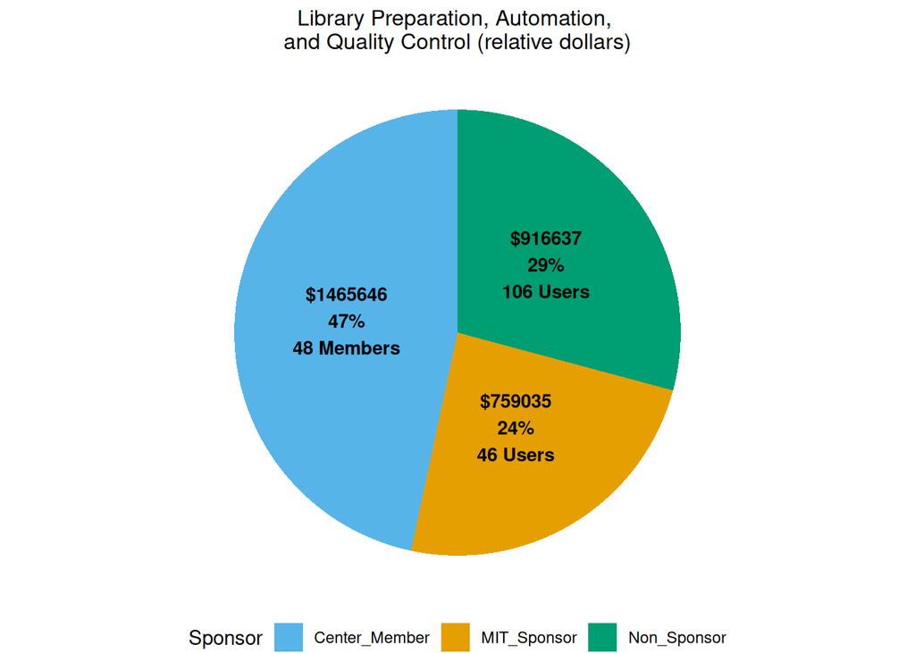

```r
lib.pie <- lib %>%
  mutate(Sponsor_ForPlot = factor(Sponsor_ForPlot, levels = sponsor_order)) %>%
  group_by(Sponsor_ForPlot) %>%
  summarise(Quantity = sum(round(Adjusted.Total.Price,0)),
            Num_Labs = if_else(first(Sponsor_ForPlot) == "Center_Member",
                               n_distinct(Faculty.Key[IGT_DSMI_Sponsor == "KI_member"]),
                               n_distinct(Faculty.Key)),
            .groups = "drop") %>%
  mutate(Percent = round((Quantity / sum(Quantity)) * 100, 0),
         Lab_Label = if_else(Sponsor_ForPlot == "Center_Member",
                             paste0(Num_Labs, " Members"),
                             paste0(Num_Labs, " Users")),
         Label = paste0("$",Quantity, "\n", Percent, "%\n", Lab_Label)) %>%
  ggplot(aes(x = "", y = Quantity, fill = Sponsor_ForPlot)) +
  geom_col() +
  geom_text(aes(label = Label),
            position = position_stack(vjust = 0.5),
            size = 3.6,
            fontface = "bold",
            color = "black") +
  coord_polar("y", start = 0) +
  scale_fill_manual(values = sponsor_colors) +
  labs(title = "Library Preparation, Automation, \nand Quality Control (relative dollars)",
       fill = "Sponsor") +
  theme_void() +
  theme(legend.position = "bottom",
        plot.title = element_text(size = 12,
                                  face = "plain",
                                  hjust = 0.5))

lib.pie
```

## Single Cell and Spatial Omics

```r
spatial <- igt.final.annot %>% dplyr::filter(group == "Single Cell and Spatial ‘Omics")
cat("Rows spatial:", dim(spatial)[1], "\n")
```

```
## Rows spatial: 524
```

```r
table(spatial$Charge.Name.Short,spatial$Unit.of.Measure)
```

```
##
##                                                      each hour service set
##   (charge) Visium - 4 slides - reagents discounted      0    0       1   0
##   10X - Amplicon - Per Sample                          78    0       0   0
##   10X - Digital Gene Expression - Per Sample          280    0       0   0
##   10X - Fixed RNA - Per 4-plex                          3    0       0   0
##   10X - Multiome - Per Sample                           8    0       0   0
##   10X - Multiplex DGE (on chip) - Pool                  7    0       0   0
##   10X - scATACseq - Per Sample                          8    0       0   0
##   10X Chromium Single Cell                              0   12       0   0
##   10X Visium FFPE - 2 sample (hs/mm only)               4    0       0   0
##   10X Visium HD- 2 sample (hs/mm only)                  9    0       0   0
##   Custom Service: BMC                                   4    0       0   0
##   NextGEM Multiome and Chip J 16 rxns                   0    0       0   0
##   SC - 10x Amp sample                                   0    0       0   0
##   SC - 10x ATAC sample                                  0    0       0   0
##   SC - 10x DGE sample                                   0    0       0   0
##   SC - 10X multi sample                                 0    0       0   0
##   SC - 10X multi Sample                                 0    0       0   0
##   SPT - VisHD 2 samples BMC                             0    0       0   0
##   SPT - Visium 4 Samples                                0    0       0   0
##   SPT - Visium Test Slide                               0    0       0   0
##   Technician Labor: General                             0    0       0   0
##   Visium Optimization Slide- Total for Quote            2    0       0   0
##   Visium Sample Slide (4 samples)- BioMicro             0    0       0   2
##   Visium: FFPE Slide (4 samples) - for quote            1    0       0   0
##   Visium: Sample Slide (4 samples)  - BioMicro         10    0       0   4
##   Visium: Sample Slide (4 samples) - Total for Quote    0    0       0   4
##
##                                                      ToUpdate
##   (charge) Visium - 4 slides - reagents discounted          0
##   10X - Amplicon - Per Sample                               0
##   10X - Digital Gene Expression - Per Sample                0
##   10X - Fixed RNA - Per 4-plex                              0
##   10X - Multiome - Per Sample                               0
##   10X - Multiplex DGE (on chip) - Pool                      0
##   10X - scATACseq - Per Sample                              0
##   10X Chromium Single Cell                                  0
##   10X Visium FFPE - 2 sample (hs/mm only)                   0
##   10X Visium HD- 2 sample (hs/mm only)                      0
##   Custom Service: BMC                                      21
##   NextGEM Multiome and Chip J 16 rxns                       1
##   SC - 10x Amp sample                                       6
##   SC - 10x ATAC sample                                      1
##   SC - 10x DGE sample                                      51
##   SC - 10X multi sample                                     1
##   SC - 10X multi Sample                                     1
##   SPT - VisHD 2 samples BMC                                 1
##   SPT - Visium 4 Samples                                    1
##   SPT - Visium Test Slide                                   1
##   Technician Labor: General                                 2
##   Visium Optimization Slide- Total for Quote                0
##   Visium Sample Slide (4 samples)- BioMicro                 0
##   Visium: FFPE Slide (4 samples) - for quote                0
##   Visium: Sample Slide (4 samples)  - BioMicro              0
##   Visium: Sample Slide (4 samples) - Total for Quote        0
```

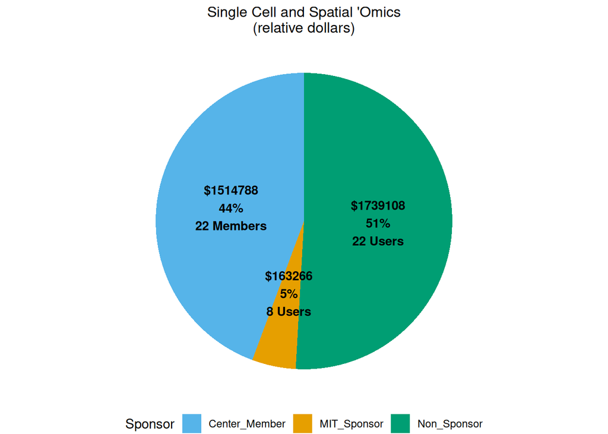

```r
spatial.pie <- spatial %>%
  mutate(Sponsor_ForPlot = factor(Sponsor_ForPlot, levels = sponsor_order)) %>%
  group_by(Sponsor_ForPlot) %>%
  summarise(Quantity = sum(round(Adjusted.Total.Price,0)),
            Num_Labs = if_else(first(Sponsor_ForPlot) == "Center_Member",
                               n_distinct(Faculty.Key[IGT_DSMI_Sponsor == "KI_member"]),
                               n_distinct(Faculty.Key)),
            .groups = "drop") %>%
  mutate(Percent = round((Quantity / sum(Quantity)) * 100, 0),
         Lab_Label = if_else(Sponsor_ForPlot == "Center_Member",
                             paste0(Num_Labs, " Members"),
                             paste0(Num_Labs, " Users")),
         Label = paste0("$",Quantity, "\n", Percent, "%\n", Lab_Label)) %>%
  ggplot(aes(x = "", y = Quantity, fill = Sponsor_ForPlot)) +
  geom_col() +
  geom_text(aes(label = Label),
            position = position_stack(vjust = 0.5),
            size = 3.6,
            fontface = "bold",
            color = "black") +
  coord_polar("y", start = 0) +
  scale_fill_manual(values = sponsor_colors) +
  labs(title = "Single Cell and Spatial 'Omics\n(relative dollars)",
       fill = "Sponsor") +
  theme_void() +
  theme(legend.position = "bottom",
        plot.title = element_text(size = 12,
                                  face = "plain",
                                  hjust = 0.5))
spatial.pie
```

## Sequencing and Oligonucleotide Synthesis

```r
seq <- igt.final.annot %>% dplyr::filter(group == "Sequencing and Oligonucleotide Synthesis")
cat("Rows seq:", dim(seq)[1], "\n")
```

```
## Rows seq: 2938
```

```r
table(seq$Charge.Name.Short,seq$Unit.of.Measure)
```

```
##
##                                          each hour lane Run ToUpdate
##   Custom Service: BMC                      33    0    0   0        4
##   Element AVITI: 150nt                     10    0    0   0        0
##   Element AVITI: 150nt flowcell            98    0    0   0        0
##   Element AVITI: 150PE lane                22    0    0   0        0
##   Element AVITI: 300nt                      2    0    0   0        0
##   Element AVITI: 300nt flowcell            40    0    0   0        0
##   Element AVITI: 600nt flowcell             7    0    0   0        0
##   Element AVITI: 75PE lane                 56    0    0   0        0
##   ELM-AVITI - 150nt FC                      0    0    0   0       10
##   ELM-AVITI - 150PE Lane                    0    0    0   0        1
##   ELM-AVITI - 300nt FC                      0    0    0   0        2
##   ELM-AVITI - 75PE Lane                     0    0    0   0        4
##   HiSeq2000: 40SE (per lane)               72    0    0   0        0
##   HiSeq2500 Rapid Run 500nt                 1    0    0   0        0
##   ILL-MiSeq - user kit                      0    0    0   0        2
##   ILL-MiSeq (150nt) v3                      0    0    0   0        4
##   ILL-MiSeq (300nt)                         0    0    0   0       13
##   ILL-MiSeq (500nt)                         0    0    0   0        1
##   ILL-MiSeq (600nt) v3                      0    0    0   0        5
##   ILL-MiSeq (Nano)                          0    0    0   0        1
##   ILL-Next  (300nt)                         0    0    0   0        5
##   ILL-Next - user kit                       0    0    0   0        2
##   ILL-Next (150nt)                          0    0    0   0       13
##   ILL-Next (300nt)                          0    0    0   0        7
##   ILL-Next (75nt)                           0    0    0   0       71
##   ILL-Nova (S1.100)                         0    0    0   0       11
##   ILL-Nova (S1.300)                         0    0    0   0        3
##   ILL-Nova (S2.100)                         0    0    0   0       11
##   ILL-Nova (S2.200)                         0    0    0   0        2
##   ILL-Nova (S2.300)                         0    0    0   0        1
##   ILL-Nova (SP.100)                         0    0    0   0       10
##   ILL-Nova (SP.300)                         0    0    0   0       13
##   ILL-Nova (SP.500)                         0    0    0   0        2
##   ILL-Nova(25B.150PE)                       0    0    0   0        1
##   ILL-Nova(S4.150PE)                        0    0    0   0       54
##   ILL-Nova(S4.50SE)                         0    0    0   0        1
##   ILL-NVX (10bL.150PE)                      0    0    0   0        3
##   ILL-NVX (25bL.150PE)                      0    0    0   0        1
```

[output cut: 42 more lines]

```
##   Oligo Instrument- assisted use            1    0    0   0        0
##   Oligo Instrument- independent use       110    0    0   0        0
##   ONT - MinION Flowcell                     0    0    0   0        1
##   ONT - PromethION                          0    0    0   0       28
##   ONT - PromethION flowcell - 48h         121    0    0   0        0
##   PAC - 20h Sequel                          0    0    0   0       15
##   PacBio Revio                              3    0    0   0        0
##   PacBio Sequel - SMRTcell 10h              2    0    0   0        0
##   PacBio Sequel - SMRTcell 20h             20    0    0   0        0
##   REVIO - 1 flowcell                        0    0    0   0        1
##   Singular G4: 150PE                       28    0    0   0        0
##   Singular G4: 50PE                       142    0    0   0        0
##   Singular G4: Rapid                        7    0    0   0        0
##   SNG - G4.F3 (150PE)                       0    0    0   0        3
##   SNG - G4.F3 (50PE)                        0    0    0   0        3
```

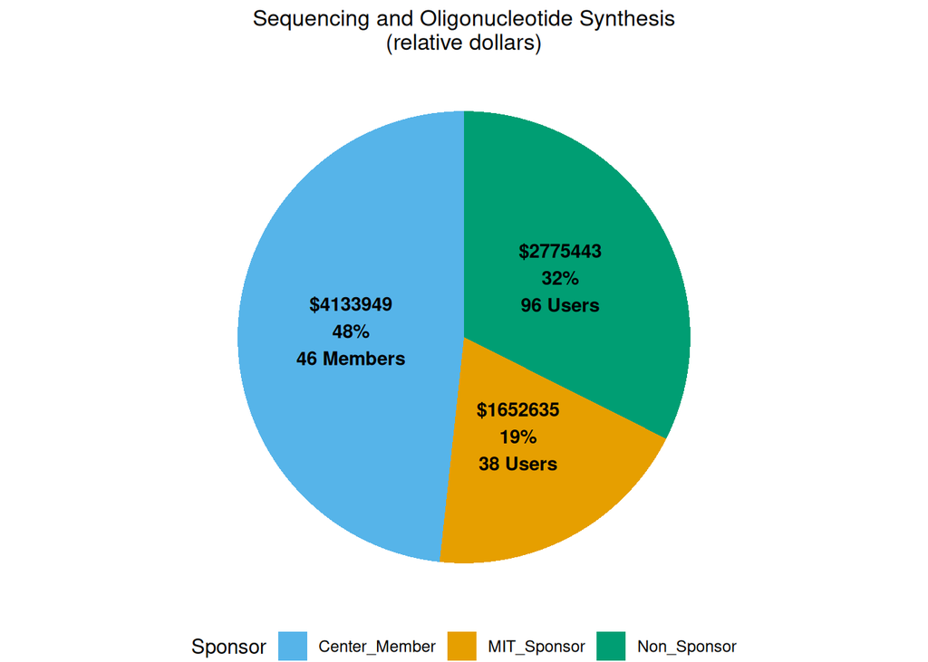

```r
seq.pie <- seq %>%
  mutate(Sponsor_ForPlot = factor(Sponsor_ForPlot, levels = sponsor_order)) %>%
  group_by(Sponsor_ForPlot) %>%
  summarise(Quantity = sum(round(Adjusted.Total.Price,0)),
            Num_Labs = if_else(first(Sponsor_ForPlot) == "Center_Member",
                               n_distinct(Faculty.Key[IGT_DSMI_Sponsor == "KI_member"]),
                               n_distinct(Faculty.Key)),
            .groups = "drop") %>%
  mutate(Percent = round((Quantity / sum(Quantity)) * 100, 0),
         Lab_Label = if_else(Sponsor_ForPlot == "Center_Member",
                             paste0(Num_Labs, " Members"),
                             paste0(Num_Labs, " Users")),
         Label = paste0("$",Quantity, "\n", Percent, "%\n", Lab_Label)) %>%
  ggplot(aes(x = "", y = Quantity, fill = Sponsor_ForPlot)) +
  geom_col() +
  geom_text(aes(label = Label),
            position = position_stack(vjust = 0.5),
            size = 3.6,
            fontface = "bold",
            color = "black") +
  coord_polar("y", start = 0) +
  scale_fill_manual(values = sponsor_colors) +
  labs(title = "Sequencing and Oligonucleotide Synthesis\n(relative dollars)",
       fill = "Sponsor") +
  theme_void() +
  theme(legend.position = "bottom",
        plot.title = element_text(size = 12,
                                  face = "plain",
                                  hjust = 0.5))

seq.pie
```

# Plot the pie charts figure

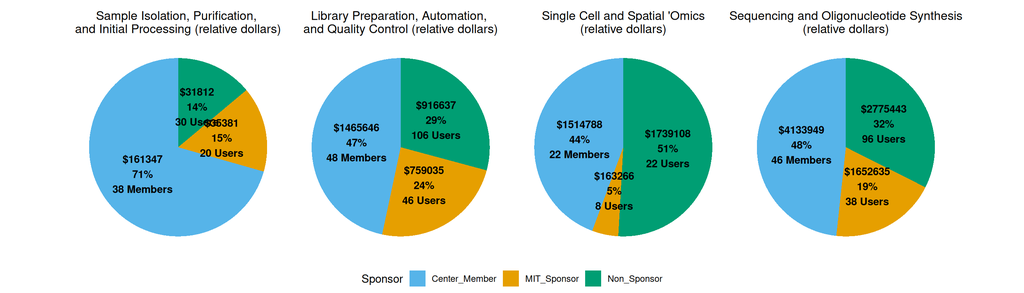

```r
samp.pie + lib.pie + spatial.pie + seq.pie + plot_layout(ncol = 4, guides = "collect") &
  theme(legend.position = "bottom")
```

```r
combo.pie <- samp.pie + lib.pie + spatial.pie + seq.pie + plot_layout(ncol = 4, guides = "collect") &
  theme(legend.position = "bottom")
ggsave("figures/IGT_combo.pie.pdf",
       plot = combo.pie,
       dpi = 600,
       width = 14,
       height = 4,
       units = "in")
```

# Write annotated output file

```r
write.xlsx(igt.final,"igt.final.xlsx")
write.xlsx(igt.final.annot,"igt.final.annot.xlsx")
```

```r
writeLines(capture.output(sessionInfo()), "IGT_processing_sessionInfo.txt")
```